# Network Analysis_HW

Isaac Kyeremateng

05-03-2025

# Load packages

In this project, I will utilize the **Mercator, igraph, ggnetwork, and ggplot2** packages to construct a network of patients diagnosed with two distinct lung cancer subtypes: **LUAD (Lung Adenocarcinoma) and LUSC (Lung Squamous Cell Carcinoma).** The network will be designed to analyze patient relationships and potential subgroup patterns within these cancer types.

```r
suppressMessages(suppressWarnings(library(Mercator)))
suppressMessages(suppressWarnings(library(igraph)))
suppressMessages(suppressWarnings(library(ggnetwork)))
suppressMessages(suppressWarnings(library(ggplot2)))
```

# Load data

Data were loaded and inspected

```r
library(readxl)
df <- readxl::read_excel("C:\\Users\\fasci\\OneDrive\\Desktop\\BMI\\2. BMDS II\\BMIDS HW 3.xlsx")
dim(df)
```

```
## [1]  387 1154
```

# Data processing

For data preprocessing, the first column (gene name) is removed as it contains character data. The dataset is then transposed to ensure column headers are properly structured. Finally, row names are converted into a new column named “subtype” to facilitate further analysis.

```r
df_new <- df[,-1]
df_new <- data.frame(t(df_new))
df_new <- cbind(subtype = rownames(df_new), df_new)
rownames(df_new) <- NULL
```

# Node-Edge Table

To create the node-edge table, key components of dataset are extracted for analysis. Patient IDs representing the values from the “subtype” column are stored separately to retain patient classification (LUAD or LUSC). Expression Data from the rest of the dataset (excluding the “subtype” column) is converted into a matrix for distance calculations and network construction.

```r
# Extract patient IDs
patient_ids <- df_new$subtype

# Extract expression data (excluding subtype column)
exp_data <- as.matrix(df_new[, -1])
```

# Patient - Patient netwrok. Q= 400

A patient similarity network is constructed based on gene expression data. First, an empty, undirected graph is created, with each node representing a patient identified by their subtype. A Euclidean distance matrix is then computed to measure similarity between patients. A threshold(Q= 400) is set to determine which patients should be connected. Finally, edges are added between patient nodes if their pairwise distance is below the threshold, forming a network where more similar patients are closely connected.

```r
# Create an empty graph
set.seed(1234)
graph3 <- make_empty_graph(n = nrow(exp_data), directed = FALSE)

# Add nodes (patients) to the graph
V(graph3)$name <- patient_ids

# Compute a distance matrix (Euclidean distance)
dist_matrix <- as.matrix(dist(exp_data, method = "euclidean"))

# Set the cutoff threshold for edge creation
Q <- 400

# Add edges based on the distance threshold
for (i in 1:(nrow(exp_data) - 1)) {
  for (j in (i + 1):nrow(exp_data)) {
    if (dist_matrix[i, j] < Q) {
      graph3 <- add_edges(graph3, c(i, j))
    }
  }
}
```

## Remove Isolated NOdes and Plot network

Patient similarity network is refined by removing isolated nodes (patients with no connections). It then ensures the remaining nodes are correctly labeled and assigns colors based on patient subtypes (LUAD or LUSC). The patient IDs are processed to extract subtype labels, which are converted into a factor for accurate color mapping. Next, the ggnetwork package is used to extract node positions while preserving their correct order. Colors are assigned accordingly, and a custom color palette is defined for visualization. The network is then plotted using ggplot2, where: • Edges represent connections between patients (with slight curvature for aesthetics). • Nodes are colored based on their subtype (LUAD in pink, LUSC in blue). • A clean, minimal theme is applied with the legend positioned at the bottom for clarity. This final visualization provides insights into the structure of patient similarity based on gene expression.

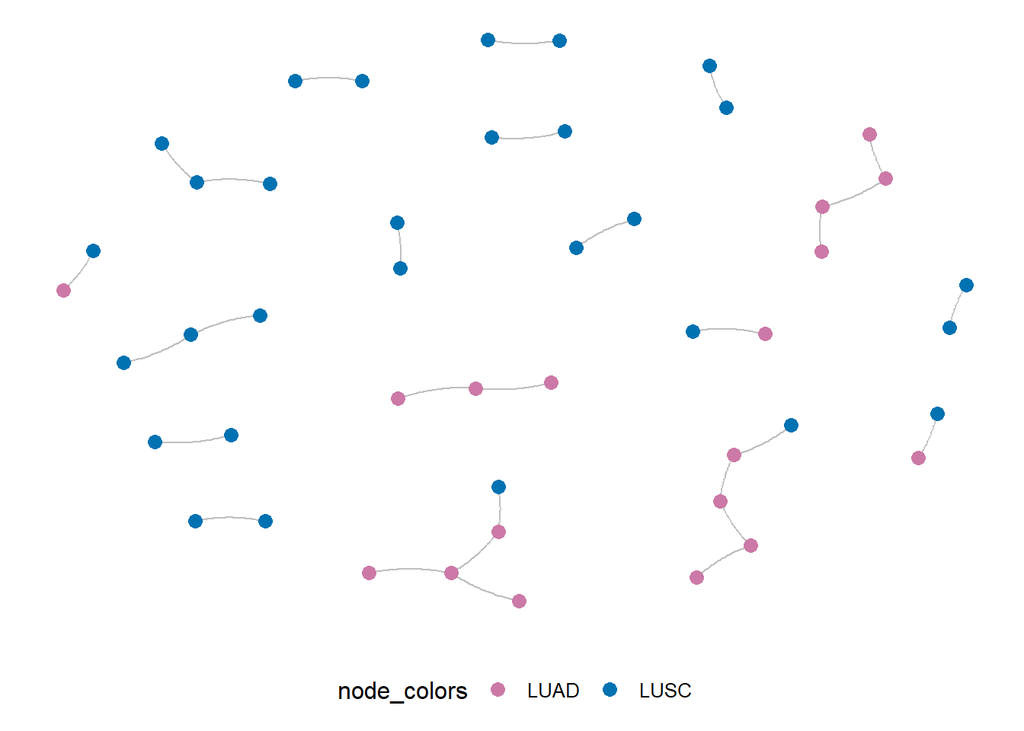

```r
# Remove isolated nodes
isolated_nodes <- which(degree(graph3) == 0)
new_graph3 <- delete_vertices(graph3, isolated_nodes)

# Ensure correct number of nodes
node_names <- V(new_graph3)$name  # Get node names
#print(length(node_names))

# Assign colors based on patient subtypes
color3 <- gsub("LUAD_\\d+", "LUAD", node_names)  # Replace patient ID with subtype
color3 <- gsub("LUSC_\\d+", "LUSC", color3)  # Ensure LUSC cases are mapped too
color3 <- as.factor(color3)  # Convert to factor for proper mapping


#print(length(color3))
#print(color3)  # Check for inconsistencies

# Extract nodes from ggnetwork to ensure proper order
network_data <- ggnetwork(new_graph3)
node_colors <- color3[match(network_data$name, node_names)]  # Match order

# Define color palette
c.palatte <- c("LUAD" = "#CC79A7", "LUSC" = "#0072B2")

# Plot network
ggplot(network_data, aes(x, y, xend = xend, yend = yend)) +
  geom_edges(alpha = 0.25, curvature = 0.1) +  # Keep edges simple
  geom_nodes(aes(color = node_colors), size = 3) +  # Ensure color is correctly mapped
  theme_blank() +
  theme(legend.position = "bottom") +
  scale_colour_manual(values = c.palatte)
```

# Q= 1000

Another patient - patient network is plotted with a Q= 1000

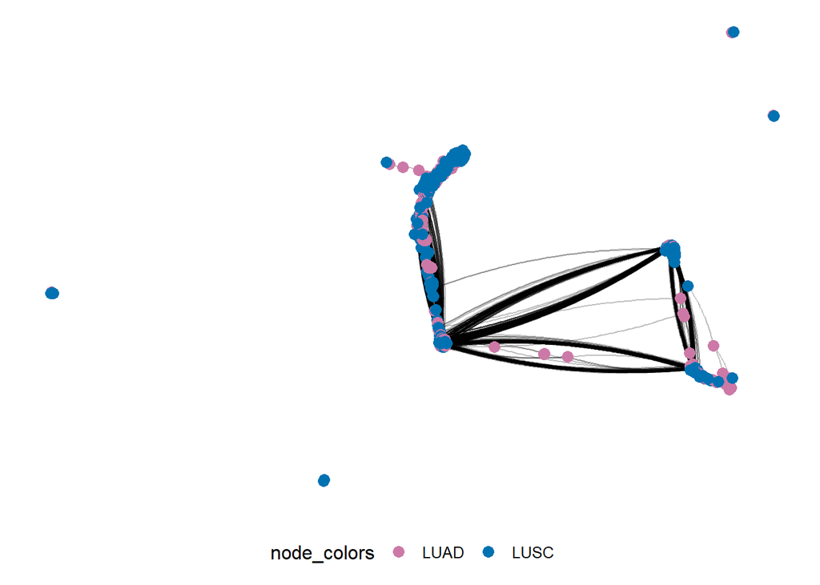

```r
set.seed(1234)
graph3 <- make_empty_graph(n = nrow(exp_data), directed = FALSE)
V(graph3)$name <- patient_ids
dist_matrix <- as.matrix(dist(exp_data, method = "euclidean"))
Q <- 1000
for (i in 1:(nrow(exp_data) - 1)) {
  for (j in (i + 1):nrow(exp_data)) {
    if (dist_matrix[i, j] < Q) {
      graph3 <- add_edges(graph3, c(i, j))
    }
  }
}
isolated_nodes <- which(degree(graph3) == 0)
new_graph3 <- delete_vertices(graph3, isolated_nodes)
node_names <- V(new_graph3)$name
#print(length(node_names))
color3 <- gsub("LUAD_\\d+", "LUAD", node_names)
color3 <- gsub("LUSC_\\d+", "LUSC", color3)
color3 <- as.factor(color3)
#print(length(color3))
#print(color3)
network_data <- ggnetwork(new_graph3)
node_colors <- color3[match(network_data$name, node_names)]
c.palatte <- c("LUAD" = "#CC79A7", "LUSC" = "#0072B2")
ggplot(network_data, aes(x, y, xend = xend, yend = yend)) +
  geom_edges(alpha = 0.25, curvature = 0.1) +
  geom_nodes(aes(color = node_colors), size = 3) +
  theme_blank() +
  theme(legend.position = "bottom") +
  scale_colour_manual(values = c.palatte)
```

# Question 2

Determine which network you believe is the most informative, write a justification for your selection, and use that network for the remainder of the homework steps 3-5.

Between the two networks, the one generated with Q = 1000 appears to be the more informative.This is because the network with Q = 1000 reveals stronger and more defined patient clusters, showing how patients with similar tumor characteristics are related. In contrast, the Q = 400 network is too sparse, making it difficult to see meaningful relationships beyond simple pairwise connections. A denser network (Q = 1000) enables the identification of potential biological or clinical subgroups among patients. The Q = 1000 network is the better choice because it provides a richer structure, stronger connections, and a more comprehensive understanding of patient clustering.

# Question 3

Identify the node that is the largest hub and identify the patient ID associated with the node, the disease label and the degrees of the hub node.

```r
# Compute node degrees
node_degrees <- degree(new_graph3)

# Identify the node with the highest degree
max_degree <- max(node_degrees)
hub_node <- V(new_graph3)$name[which(node_degrees == max_degree)]

# Extract patient ID and disease label
patient_id <- hub_node
disease_label <- ifelse(grepl("LUAD", patient_id), "LUAD", "LUSC")

# Print results
cat("Largest Hub Node:", patient_id, "\n")
```

```
## Largest Hub Node: LUSC_475
```

```r
cat("Associated Disease:", disease_label, "\n")
```

```
## Associated Disease: LUSC
```

```r
cat("Degree of Hub Node:", max_degree, "\n")
```

```
## Degree of Hub Node: 221
```

# Question 4

Generate a histogram showing the distribution of degrees across all nodes in your network. Please provide a written interpretation of the distribution and explain how you would interpret the plot.

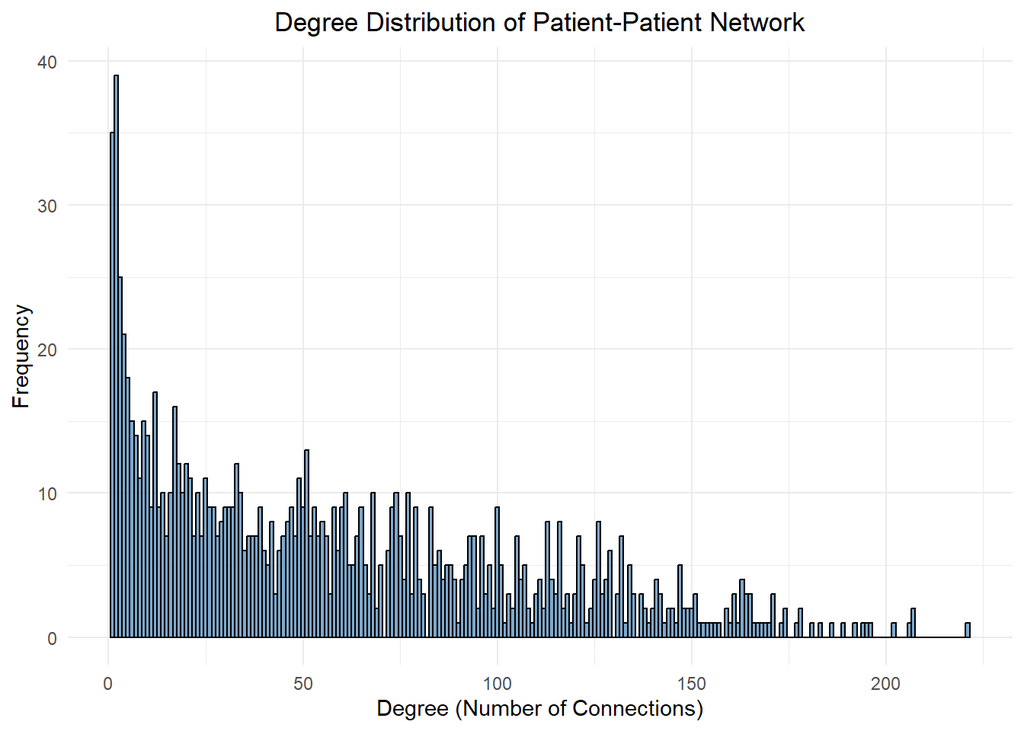

```r
# Compute node degrees
node_degrees <- degree(new_graph3)

# Convert to a data frame for visualization
degree_df <- data.frame(Degree = node_degrees)

# Plot histogram
ggplot(degree_df, aes(x = Degree)) +
  geom_histogram(binwidth = 1, fill = "steelblue", color = "black", alpha = 0.7) +
  theme_minimal() +
  labs(title = "Degree Distribution of Patient-Patient Network",
       x = "Degree (Number of Connections)",
       y = "Frequency") +
  theme(plot.title = element_text(hjust = 0.5))
```

Observations: The histogram has a right-skewed distribution. The majority of nodes (patients) have low-degree values (fewer connections), while only a small number of nodes have high-degree values. This suggests that most patients have limited direct connections, while a few highly connected patients (hubs) dominate the network.

The presence of high-degree nodes (with connections exceeding 100) indicates that some patients serve as hub nodes,linking multiple patients together. These hubs might share common genetic profiles, clinical characteristics, or risk factors, making them highly similar to many other patients.

# Question 5

Calculate the total graph density and the density within both subtypes (luad, lusc). Based on these calculations, please write a discussion section or you discuss how informative you believe this network is based on its structure and density. In addition please describe if you believe this network is useful in distinguishing between the two cancer subtypes and why.

```r
# Calculate overall graph density
overall_density <- edge_density(new_graph3)

# Extract LUAD and LUSC nodes
luad_nodes <- V(new_graph3)$name[grepl("LUAD", V(new_graph3)$name)]
lusc_nodes <- V(new_graph3)$name[grepl("LUSC", V(new_graph3)$name)]

# Create subgraphs for each subtype
luad_subgraph <- induced_subgraph(new_graph3, vids = luad_nodes)
lusc_subgraph <- induced_subgraph(new_graph3, vids = lusc_nodes)

# Calculate densities for each subtype
luad_density <- edge_density(luad_subgraph)
lusc_density <- edge_density(lusc_subgraph)

# Print results
cat("Overall Graph Density:", overall_density, "\n")
```

```
## Overall Graph Density: 0.05377453
```

```r
cat("LUAD Subnetwork Density:", luad_density, "\n")
```

```
## LUAD Subnetwork Density: 0.05991838
```

```r
cat("LUSC Subnetwork Density:", lusc_density, "\n")
```

```
## LUSC Subnetwork Density: 0.08156923
```

# Discussion

The network analysis of patient-patient relationships in lung cancer, based on gene expression similarity, provides valuable insights into the structural organization and connectivity within and across cancer subtypes. The overall graph density of 0.0538 suggests that while connections exist between patients, the network is relatively sparse, meaning that most patients share similarities with only a limited number of others. This aligns with the biological understanding that lung cancer is a heterogeneous disease, where patient profiles vary widely based on genetic, molecular, and clinical characteristics. Interpretation of Density in Subtypes The LUAD subnetwork density (0.0599) is slightly higher than the overall network density, indicating that LUAD patients tend to cluster together more than expected by chance but still exhibit a moderate level of diversity. On the other hand, the LUSC subnetwork density (0.0816) is noticeably higher than that of LUAD, suggesting that LUSC patients are more tightly connected and exhibit greater intra-subtype similarity compared to LUAD. These findings may suggest that LUSC tumors have more homogeneous gene expression profiles, leading to stronger connections within the LUSC subgroup, while LUAD tumors are more diverse, leading to a looser network structure.

# Conclusion

This network analysis provides a meaningful representation of lung cancer subtypes based on gene expression similarity. The differences in density between LUAD and LUSC suggest that this approach can help distinguish between the two subtypes, particularly for identifying homogeneous subgroups within LUSC. However, the relatively low overall density suggests that additional layers of data may be needed to improve the resolution of patient relationships and refine subtype classification.